# Data Wrangling in R

Xiaorui (Jeremy) Zhu

01/08/2026

# Importance of Data Wrangling!

[figure not shown]

> “Unless the data is something I’ve analyzed a lot before, I usually feel like the blind men and the elephant.” – Jeff Leek

# Most Time-Consuming Data Science Task: Data Cleaning

80% of the work - [**Data preparation** accounts for about 80% of the work of data scientists](https://www.forbes.com/sites/gilpress/2016/03/23/data-preparation-most-time-consuming-least-enjoyable-data-science-task-survey-says/#6a089d126f63)

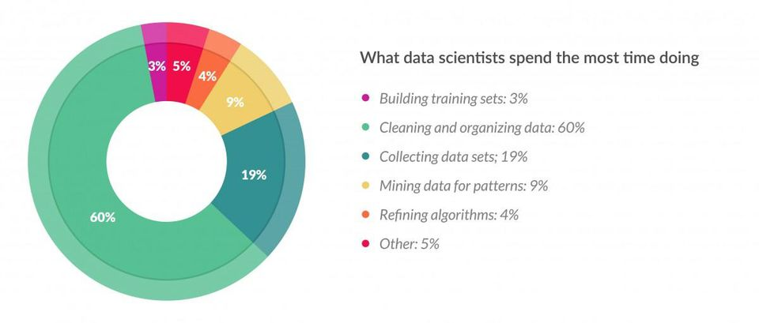

# Data Cleaning: ensure $\color{red}{\text{reliability}}$ and $\color{red}{\text{quality}}$

In business analytics, data comes from various sources such as databases, spreadsheets, and external sources. These sources often contain missing values, duplicate entries, outliers, and formatting inconsistencies, which can strongly skew the analysis results and lead to incorrect business decisions if not addressed properly.

Data cleaning is a crucial step in the process of preparing data for analysis in the field of business analytics. It involves *identifying and correcting* errors, inconsistencies, and inaccuracies in the dataset to ensure its **reliability** and **quality**.

# WHY data cleaning is a crucial step

- Organizational data often represent multiple truths
- Organizations are increasingly integrating internal and external data sources
- Analysts need to understand what assumptions or nuances are represented by the data

# Do you enjoy it?

> It is important and time-consuming,

> but, do you enjoy data cleaning?

# Data Wrangling in R

In R programming language, data wrangling skills are essential for efficiently manipulating and preparing data for analysis. Some important data wrangling skills in R include:

1. Data Importing
2. Data Cleaning
3. Data Transformation
4. Data Manipulation
5. Data Visualization
6. Handling Dates and Times
7. Handling Strings
8. Looping and Conditional Statements
9. Efficient Coding Practices

By performing thorough data cleaning, business analysts can improve the quality and reliability of their analyses, leading to more accurate insights and better-informed business decisions. It lays the foundation for successful data analysis and ensures that businesses can trust the results derived from their data-driven initiatives.

# Data Importing

R supports the importing from various sources such as CSV files, Excel spreadsheets, databases (e.g., MySQL, PostgreSQL), web APIs, and other formats.

| Option | Function | Speed in seconds |
| --- | --- | --- |
| Base R | `read.csv("data/flights.csv")` | ~ 4 seconds |
| `library(readr)` | `read_csv("data/flights.csv")` | ~ 0.8 seconds |
| `library(data.table)` | `fread("data/flights.csv")` | ~ 0.3 seconds |
| `library(readxl)` | `read_excel()` |  |
| Database: `library(DBI)` | `dbSendQuery()` |  |
| Web APIs: `library(httr)` | `GET(url = NULL,...)` |  |

# Data Importing

## What about other flat files?

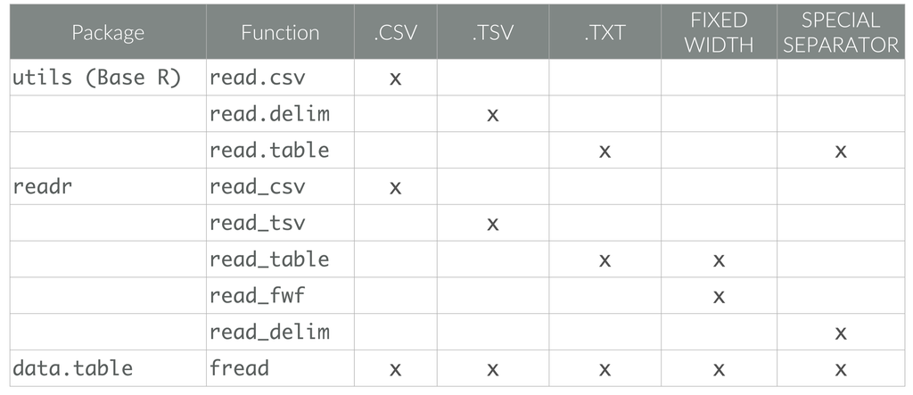

# Examples: `read.csv()` and `read_excel()`

We focus on `read.csv()` function to read in .csv files, and `read_excel()` to read in .xlsx files.

1. Example 1: Importing data from a CSV file (Auto.csv)

```r
Auto <- read.csv("data/Auto.csv")
# View(Auto)
head(Auto)
```

```
##   mpg cylinders displacement horsepower weight acceleration year origin
## 1  18         8          307        130   3504         12.0   70      1
## 2  15         8          350        165   3693         11.5   70      1
## 3  18         8          318        150   3436         11.0   70      1
## 4  16         8          304        150   3433         12.0   70      1
## 5  17         8          302        140   3449         10.5   70      1
## 6  15         8          429        198   4341         10.0   70      1
##                        name
## 1 chevrolet chevelle malibu
## 2         buick skylark 320
## 3        plymouth satellite
## 4             amc rebel sst
## 5               ford torino
## 6          ford galaxie 500
```

2. Example 2: Importing data from an Excel spreadsheet

(RetailSales2018.xlsx); (RetailSales2018_clean.xlsx)

```r
library(readxl)
Retail <- read_xlsx(path = "data/RetailSales2018.xlsx")
head(Retail)
```

```
## # A tibble: 6 × 5
##   RETAIL & FOOD SERVICES(http://www.census.gov/retail/…¹ ...2  ...3  ...4  ...5
##   <chr>                                                  <chr> <chr> <chr> <chr>
## 1 SEASONAL FACTORS(http://www.census.gov/retail/marts/w… <NA>  <NA>  <NA>  <NA>
## 2 CPI Table 24(http://www.bls.gov/cpi)                   <NA>  <NA>  <NA>  <NA>
## 3 <NA>                                                   <NA>  <NA>  <NA>  <NA>
## 4 <NA>                                                   <NA>  <NA>  <NA>  <NA>
## 5 Year                                                   Month Sales S_Fa… CPI
## 6 1992                                                   JAN   1471… 0.89… 138.1
## # ℹ abbreviated name:
## #   ¹`RETAIL & FOOD SERVICES(http://www.census.gov/retail/marts/www/timeseries.html)`
```

# Learn about the data

- So what are the first things we want to know about our data?
- ?
- ?
- ?
- ?

# Data Cleaning

Skills to clean and preprocess data, which may involve handling missing values (`NA`), removing duplicates, converting data types, dealing with outliers, and detecting and correcting errors in the dataset using functions like `na.omit()`, `complete.cases()`, `duplicated()`, and various functions from the `dplyr` and `tidyr` packages.

# Data Cleaning

- `na.omit()` : Removes any rows that contain at least one NA.

```r
df <- data.frame(
  x = c(1, 2, NA),
  y = c(4, NA, 6)
)

na.omit(df)
```

```
##   x y
## 1 1 4
```

# Data Cleaning

- `complete.cases()` : Returns a logical vector indicating which rows have no missing values.

```r
complete.cases(df)
```

```
## [1]  TRUE FALSE FALSE
```

# Data Cleaning

- `duplicated()`: Identifies duplicate values or rows, marking all but the first occurrence as TRUE.

```r
x <- c(1, 2, 2, 3, 1)
duplicated(x)
```

```
## [1] FALSE FALSE  TRUE FALSE  TRUE
```

# Data Cleaning

## Example 1: Removing useless rows

```r
Retail2 <- Retail[-c(1:4),]
head(Retail2)
```

```
## # A tibble: 6 × 5
##   RETAIL & FOOD SERVICES(http://www.census.gov/retail/…¹ ...2  ...3  ...4  ...5
##   <chr>                                                  <chr> <chr> <chr> <chr>
## 1 Year                                                   Month Sales S_Fa… CPI
## 2 1992                                                   JAN   1471… 0.89… 138.1
## 3 1992                                                   FEB   1470… 0.89… 138.6
## 4 1992                                                   MAR   1596… 0.97… 139.…
## 5 1992                                                   APR   1636… 0.99… 139.5
## 6 1992                                                   MAY   1700… 1.02… 139.…
## # ℹ abbreviated name:
## #   ¹`RETAIL & FOOD SERVICES(http://www.census.gov/retail/marts/www/timeseries.html)`
```

```r
# Change colomn names
names(Retail2) <- as.character(Retail2[1, ])
Retail2 <- Retail2[-1, ]
Retail2[1:3,]
```

```
## # A tibble: 3 × 5
##   Year  Month Sales              S_Factor            CPI
##   <chr> <chr> <chr>              <chr>               <chr>
## 1 1992  JAN   147182.451         0.89700000000000002 138.1
## 2 1992  FEB   147012.70000000001 0.89500000000000002 138.6
## 3 1992  MAR   159653.32499999998 0.97499999999999998 139.30000000000001
```

# Data Cleaning

## Example 2: Handling missing values

```r
clean_Retail <- na.omit(Retail2)
dim(clean_Retail)
```

```
## [1] 318   5
```

# Data Cleaning

## Example 3: Removing duplicates:

```r
clean_Retail2 <- clean_Retail[!duplicated(clean_Retail), ]
dim(clean_Retail2)
```

```
## [1] 318   5
```

# Data Transformation

Ability to transform data by creating new variables, reshaping data from wide to long format (and vice versa), and summarizing data using functions like `mutate()`, `select()`, `filter()`, `arrange()`, `group_by()`, `summarize()` from the `dplyr` package, and functions like `pivot_longer()` and `pivot_wider()` from the `tidyr` package.

# Data Manipulation

Skills to perform various data manipulation tasks such as merging/joining datasets, splitting data into subsets, and reshaping data using functions like `merge()`, `join()`, `split()`, `reshape()`, `rbind()`, `cbind()`.

# Data Visualization

For quick data exploration, base R plotting functions can provide an expeditious and straightforward approach to understanding your data. Data visualization skills are the abilities to visualize data to explore patterns, relationships, and trends using functions like `ggplot2` for creating sophisticated and customizable plots, `plot()` for basic plots, and `ggplotly()` from the `plotly` package for interactive plots.

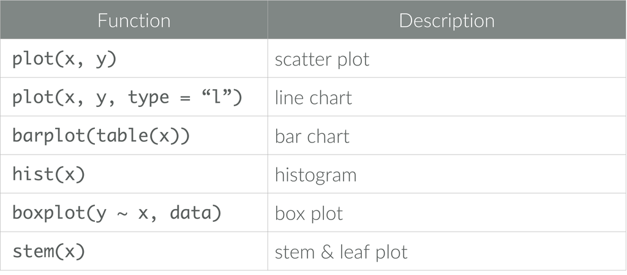

# Handling Dates and Times

Skills to work with date and time data, including parsing, formatting, extracting components (e.g., year, month, day), and performing date arithmetic using functions like `as.Date()`, `as.POSIXct()`, `strftime()`, `strptime()`, `lubridate` package.

# Handling Strings

Ability to manipulate and process character strings, including pattern matching, substring extraction, and string manipulation using functions like `grep()`, `sub()`, `gsub()`, `strsplit()`, and `stringr` package.

# Looping and Conditional Statements

Understanding of control structures like loops (`for`, `while`) and conditional statements (`if`, `else`, `ifelse`) to automate repetitive tasks and apply conditional operations on data.

# Efficient Coding Practices

Familiarity with efficient coding practices such as vectorization, using R’s apply family of functions (`apply()`, `lapply()`, `sapply()`, `vapply()`, `mapply()`), and leveraging the capabilities of packages like `dplyr` and `tidyr` for faster and more concise code.

These skills are crucial for effectively managing and preparing data for analysis and visualization tasks in R. Continuous practice and exploration of R packages and functions related to data wrangling will enhance proficiency in handling diverse datasets and extracting meaningful insights.

# Time to flex our new knowledge muscles!

[figure not shown]

Let’s apply what you’ve learned to a real case.

go to top

[go back to course website](https://xiaorui.site/Data-Mining-Business-Analytics/)